# FinalProject

## Analyzing Airbnb data in the Washington DC area

With data from Airbnb on Washington DC area listings and reviews, we look to make a predictive model of listing price based on the number of ratings of Airbnb listings. This hypothesis follows from the obsevations of data patterns, as explored below. I suggest that this pattern is as a result of listings that are considered good deals will attract more customers, and customers who believe they have recieved a good deal are more likely to leave a review. As observed, reviews are likely to be positive, and there is little correlation between review scores and price of a listing relative to the mean. It is also likely that those listings which are good deals and able to accrue more customers are more sustainable and so remain on the market longer than inappropriately priced listings.

In this tutorial we outline the data science pipeline, from data acquisition and parsing to model creation. In this example, data was already accumulated by Airbnb, and so acquisition was simply downloading the csv file from their data repository. We then parsed the data file and selected data columns we wished to analyze.

## Organizing Data

We only need some of the data provided, the essentail data we will use later on are the coordinates, the price, the neighbourhood, and the number of reviews for each listing.

```r
listings <- full_listings %>% select(
    id,
    host_id,
    neighbourhood,
    zipcode,
    latitude,
    longitude,
    accommodates,
    price,
    number_of_reviews,
    review_scores_rating,
    reviews_per_month)

listings %>% head()
```

```
## # A tibble: 6 x 11
##      id host_id neighbourhood zipcode latitude longitude accommodates price
##   <dbl>   <dbl> <chr>         <chr>      <dbl>     <dbl>        <dbl> <chr>
## 1  3344    4957 Downtown/Pen~ 20005       38.9     -77.0            1 $48.~
## 2  3362    2798 Shaw          20001       38.9     -77.0           16 $433~
## 3  3662    4645 Buena Vista   20020       38.9     -77.0            1 $65.~
## 4  3686    4645 Anacostia     20020       38.9     -77.0            1 $55.~
## 5  3771    4795 Mount Pleasa~ 20009       38.9     -77.0            2 $88.~
## 6  4197    5061 Capitol Hill  20003       38.9     -77.0            2 $83.~
## # ... with 3 more variables: number_of_reviews <dbl>,
## #   review_scores_rating <dbl>, reviews_per_month <dbl>
```

## Summarizing Data

First off, let’s see how everything looks. For simplicity, we will first take a look at the top ten neighbourhoods based on price.

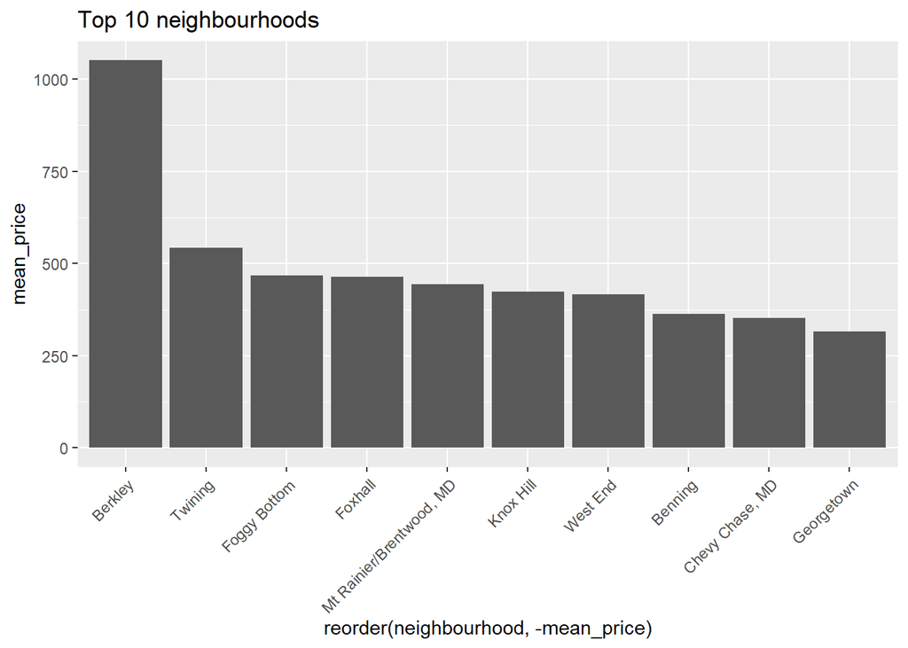

```r
listings$price <- as.numeric(gsub('[$,]', '', listings$price))
listings <- listings %>%
  mutate(adj_price = (price/accommodates))

top_ten_neighbourhoods <- listings %>%
  group_by(neighbourhood) %>%
  summarize(mean_price=mean(price), latitude=mean(latitude), longitude=mean(longitude)) %>%
  arrange(desc(mean_price)) %>%
  slice(1:10)

top_ten_neighbourhoods %>%
  ggplot(aes(x=reorder(neighbourhood,-mean_price), y=mean_price)) +
  geom_bar(stat="identity") +
  ggtitle("Top 10 neighbourhoods") +
  theme(axis.text.x = element_text(angle = 45, hjust = 1))
```

And let’s see where these neighborhoods are.

```r
pal <- colorFactor("Paired", top_ten_neighbourhoods$neighbourhood)

leaflet(top_ten_neighbourhoods) %>%
  addTiles() %>%
  setView(lat=38.9, lng=-77.10, zoom=11) %>%
  addCircleMarkers(radius = 8,
    color = ~pal(neighbourhood),
    stroke = TRUE, fillOpacity = 1) %>%
  addLegend("bottomleft",
    pal = pal,
    values = ~reorder(neighbourhood,-mean_price),
    title = "Top 10 Neighborhoods",
    opacity = 1
  )
```

```
## Assuming "longitude" and "latitude" are longitude and latitude, respectively
```

[interactive chart not shown]

What if we look at the ratings of properties vs their price.

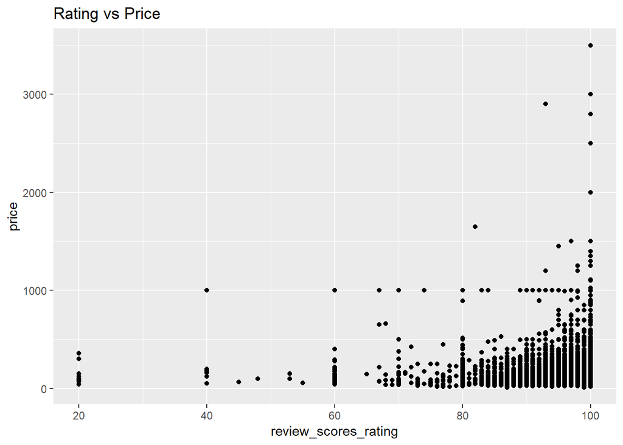

```r
listings %>%
  filter(!is.na(review_scores_rating)) %>%
  ggplot(aes(x=review_scores_rating, y=price)) +
  geom_point() +
  ggtitle("Rating vs Price")
```

We see that surprisingly, there seems to be very little correlation between the score of a listing (its rating) and its price. What if we look at the number of reviews for each listing instead? We suspect there should be some correlation between how many reviews a listing has and how good of a listing it is.

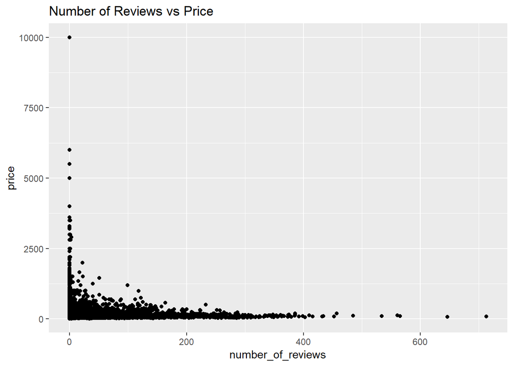

```r
listings %>%
  filter(!is.na(number_of_reviews)) %>%
  ggplot(aes(x=number_of_reviews, y=price)) +
  geom_point() +
  ggtitle("Number of Reviews vs Price")
```

From this we can see some sort of trend, but what exactly is it? Let’s take a closer look.

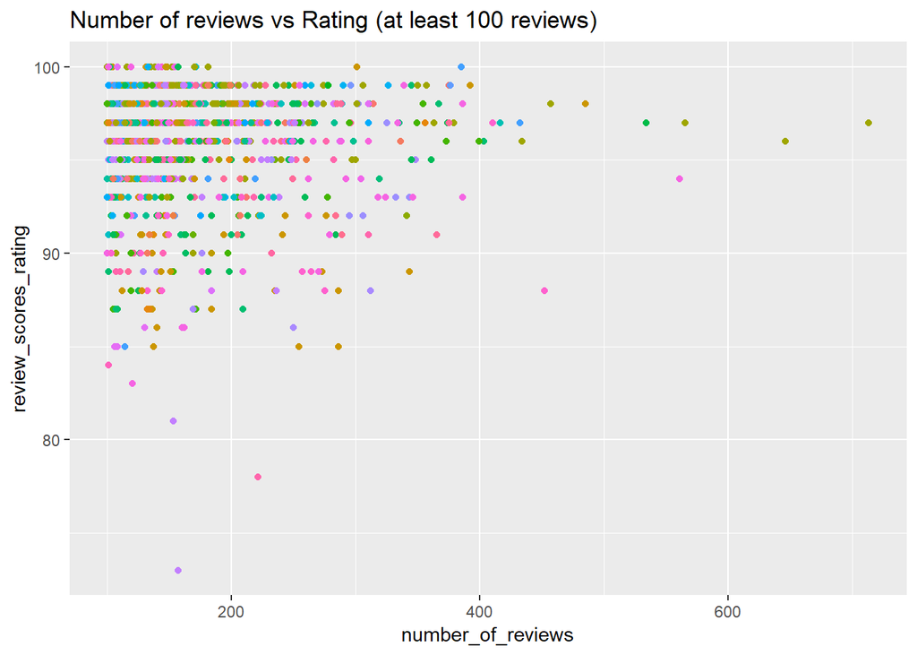

```r
listings %>%
  filter(!is.na(review_scores_rating)) %>%
  filter(number_of_reviews >= 100) %>%
  ggplot(aes(x=number_of_reviews, y=review_scores_rating, color=neighbourhood)) +
  geom_point(show.legend = FALSE) +
  ggtitle("Number of reviews vs Rating (at least 100 reviews)")
```

## Finding performance within a neighbourhood

We want to find which listings are likely to be good deals, lets see how the price of each listing compares with the average in its neighbourhood.

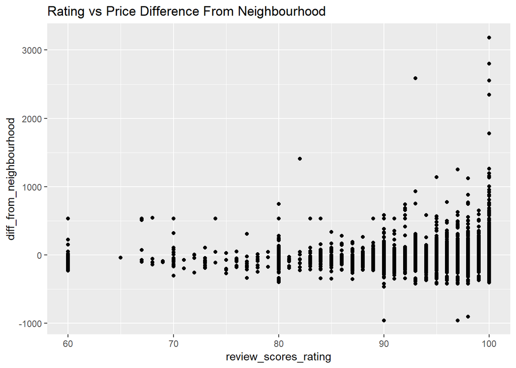

```r
listings %>%
  group_by(neighbourhood) %>%
  mutate(diff_from_neighbourhood = price-mean(price)) %>%
  filter(review_scores_rating >= 60) %>%
  ggplot(aes(x=review_scores_rating, y=diff_from_neighbourhood)) +
  geom_point() +
  ggtitle("Rating vs Price Difference From Neighbourhood")
```

Again we see very little to interpret from the review scores. From this we can suspect that there is no correlation between review scores and the price of a listing. Perhaps this is due to reviews on a listing likely to be skewed positive, and in general people unlikely to book a poorly priced listing and so unable to leave a review. From this suspicion, it follows that the number of reviews of a listing should be indicative of how many people book a listing, and from that how many people think a listing is a good deal.

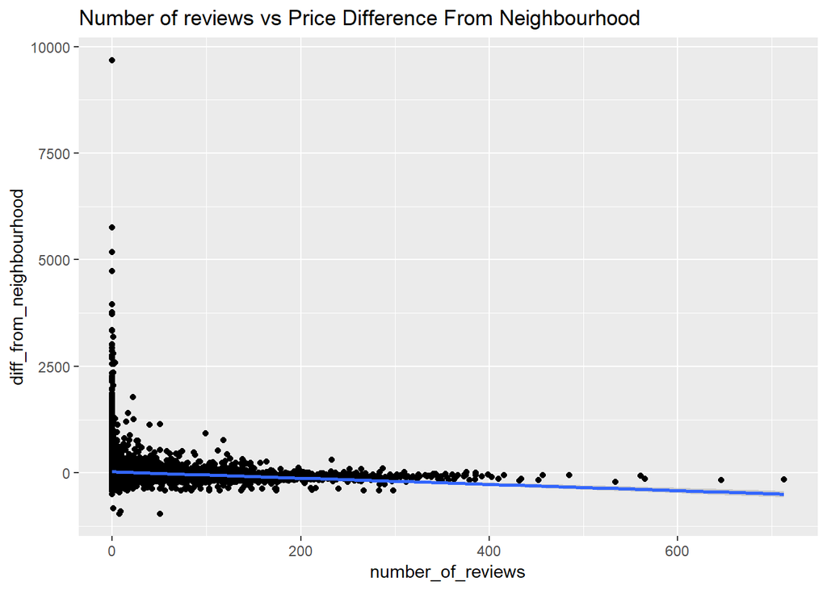

```r
listings %>%
  group_by(neighbourhood) %>%
  mutate(diff_from_neighbourhood = price-mean(price)) %>%
  filter(!(is.na(number_of_reviews))) %>%
  ggplot(aes(x=number_of_reviews, y=diff_from_neighbourhood)) +
  geom_point() +
  geom_smooth(method=lm) +
  ggtitle("Number of reviews vs Price Difference From Neighbourhood")
```

Let’s try to isolate locations with at least 10 reviews, so that there isn’t such a skew at ~1 review. We also make sure to divide by the mean price so that there is no scale issue, where neighbourhoods with higher price listings are likely to be farther from the average because there is a greater range of prices.

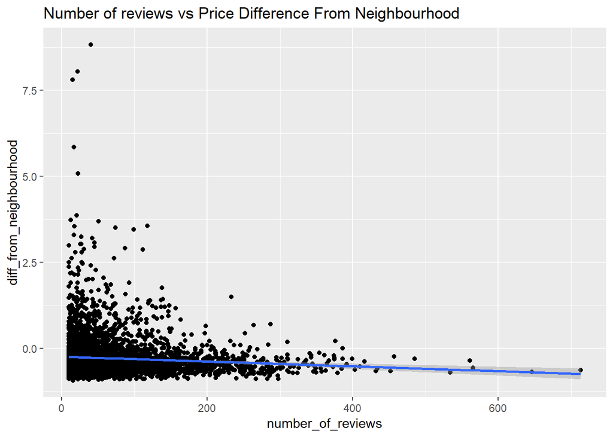

```r
tmp <- listings %>%
  group_by(neighbourhood) %>%
  mutate(diff_from_neighbourhood = (price-mean(price))/mean(price)) %>%
  filter(number_of_reviews>=10)

tmp %>%
  ggplot(aes(x=number_of_reviews, y=diff_from_neighbourhood)) +
  geom_point() +
  geom_smooth(method=lm) +
  ggtitle("Number of reviews vs Price Difference From Neighbourhood")
```

From this we can see there may be a correlation between the number of reviews a location has and its price relative to the neighbourhood it is in, namely that locations with more reviews are likely to be less expensive than other listings in their respective neighbourhood.

```r
review_fit <- lm(diff_from_neighbourhood~number_of_reviews, data=tmp)

review_fit
```

```
##
## Call:
## lm(formula = diff_from_neighbourhood ~ number_of_reviews, data = tmp)
##
## Coefficients:
##       (Intercept)  number_of_reviews
##        -0.2407977         -0.0007027
```

Let’s look at the stats for our fit, how good of a model is it?

```r
review_stats <- review_fit %>%
  broom::tidy()

review_stats
```

```
## # A tibble: 2 x 5
##   term               estimate std.error statistic  p.value
##   <chr>                 <dbl>     <dbl>     <dbl>    <dbl>
## 1 (Intercept)       -0.241     0.0117      -20.5  1.67e-89
## 2 number_of_reviews -0.000703  0.000121     -5.80 7.19e- 9
```

From this we can say we have found a statistically significant relationship between the number of reviews of a listing and its relative price to the average of its neighbourhood. Namely, a listing is likely to be cheaper by ( *{0.00058} 0.00070* {0.00082} ) relative to the mean price of its neighbourhood per review it has.

## On the hunt for a good deal

Let’s try to visualize where these good deals may be. First lets just look at which listings are above their neighbourhood’s mean, and which are below.

```r
tmp <- listings %>%
  group_by(neighbourhood) %>%
  mutate(diff_from_neighbourhood = price-mean(price)) %>%
  mutate(is_good_deal = (diff_from_neighbourhood <= 0))



pal <- colorFactor(c("green", "red"), c(TRUE, FALSE))

leaflet(tmp) %>%
  addTiles() %>%
  setView(lat=38.9, lng=-77.10, zoom=11) %>%
  addCircleMarkers(radius = 2,
    color = ~pal(is_good_deal),
    stroke = TRUE, fillOpacity = 0.7)
```

```
## Assuming "longitude" and "latitude" are longitude and latitude, respectively
```

[interactive chart not shown]

Now let’s apply our model and see how good of a predictor we made. We define a good deal to be a property whose difference from neighbourhood price is actually lower than what we would predict from our model.

```r
slope_val <- review_fit$coefficients[2]
intercept_val <- review_fit$coefficients[1]

tmp <- listings %>%
  group_by(neighbourhood) %>%
  mutate(diff_from_neighbourhood = (price-mean(price))/mean(price)) %>%
  mutate(prediction = (number_of_reviews * slope_val + intercept_val)) %>%
  mutate(is_good_deal = (diff_from_neighbourhood <= prediction))


pal <- colorFactor(c("green", "red"), c(TRUE, FALSE))

leaflet(tmp) %>%
  addTiles() %>%
  setView(lat=38.9, lng=-77.10, zoom=11) %>%
  addCircleMarkers(radius = 2,
    color = ~pal(is_good_deal),
    stroke = TRUE, fillOpacity = 0.7)
```

```
## Assuming "longitude" and "latitude" are longitude and latitude, respectively
```

[interactive chart not shown]

```r
slope_val <- review_fit$coefficients[2]
intercept_val <- review_fit$coefficients[1]

tmp <- listings %>%
  group_by(neighbourhood) %>%
  mutate(diff_from_neighbourhood = (price-mean(price))/mean(price)) %>%
  mutate(prediction = (number_of_reviews * slope_val + intercept_val)) %>%
  mutate(is_good_prediction = ((diff_from_neighbourhood <= 0) && (diff_from_neighbourhood <= prediction)))

tmp %>% filter(neighbourhood=="Shaw")
```

```
## # A tibble: 403 x 15
## # Groups:   neighbourhood [1]
##        id host_id neighbourhood zipcode latitude longitude accommodates
##     <dbl>   <dbl> <chr>         <chr>      <dbl>     <dbl>        <dbl>
##  1   3362    2798 Shaw          20001       38.9     -77.0           16
##  2   4501    1585 Shaw          20001       38.9     -77.0            2
##  3  25366    2798 Shaw          20001       38.9     -77.0           11
##  4  32584   29711 Shaw          20001       38.9     -77.0            4
##  5  52092   50148 Shaw          20001       38.9     -77.0            6
##  6  93551  481929 Shaw          20001       38.9     -77.0            2
##  7 124030  614408 Shaw          20001       38.9     -77.0            4
##  8 175608   50148 Shaw          20001       38.9     -77.0            4
##  9 198761  970466 Shaw          20001       38.9     -77.0            1
## 10 407014   29711 Shaw          20001       38.9     -77.0            6
## # ... with 393 more rows, and 8 more variables: price <dbl>,
## #   number_of_reviews <dbl>, review_scores_rating <dbl>,
## #   reviews_per_month <dbl>, adj_price <dbl>,
## #   diff_from_neighbourhood <dbl>, prediction <dbl>,
## #   is_good_prediction <lgl>
```

```r
pal <- colorFactor(c("green", "red"), c(TRUE, FALSE))

leaflet(tmp) %>%
  addTiles() %>%
  setView(lat=38.9, lng=-77.10, zoom=11) %>%
  addCircleMarkers(radius = 2,
    color = ~pal(is_good_prediction),
    stroke = TRUE, fillOpacity = 0.7)
```

```
## Assuming "longitude" and "latitude" are longitude and latitude, respectively
```

[interactive chart not shown]

From this we can see locations where both the model and our definition determined the listing to be a good deal.

From start to end, the data science pipeline can be described as follows:

#### 1. Acquire data

We used data from Airbnb (http://insideairbnb.com/get-the-data.html) descriptions of the dataset and more can be found at the link. To read the data we used the readcsv function. We then selected the appropriate columns with which we wished to model our data and form our hypothesis.

#### 2. Look at the data to see any trends

We then plot some variables to see if we can notice any trends. We make some informed guesses about how the data may look, and use how each plot looks to informs how we might improve our model. For information about map plotting see (https://rstudio.github.io/leaflet/).

#### 3. Create a model using Linear Regression

Once we have notice a trend, from that we can form a hypothesis about how the data should depend on certain variables. We can solve for this dependency using linear regression, supposing the data follows a linear trend. For more information about linear regression in r see (http://www.hcbravo.org/IntroDataSci/bookdown-notes/linear-regression.html). For more information about linear regression see (http://www.stat.yale.edu/Courses/1997-98/101/linreg.htm). Once we have a model, we can examine how good of a fit it is to our data by looking at its statistics. The p-value of a model tells how likely the null hypothesis is. A p-value less than 0.05 suggests that the null hypothesis can be rejected. For more information about the p-value see (https://www.investopedia.com/terms/p/p-value.asp).

#### 4. Apply our model and reflect

Now that we have our model, lets apply it to our data and see how well our predictions match our measurements. One way to examine our model is to predict the relative price of listings with respect to the number of reviews. Another way would be to isolate a portion of our dataset for testing purposes, or collect another sample to test our model on. By varying our samples we can avoid overtraining our model to work well for a specific dataset, but only for that dataset and not generalizable for the properties we wish to examine.